# week_13

b06208016楊鎧綾

December 7, 2018

## 3.12

### a

**the response variable(y) is height;and the explanatory variable(x) is mid-parent height**

### b

```r
height_m=c(71,70,74,67,65,72,68,74)
height_f=c(60,66,65,66,67,63,69,63,61,65)
parheight_m=c(64,64.5,72.5,64,63,69,67,69.5)
parheight_f=c(63.5,67,65.5,69.5,67.5,65.5,70,63,63,67.5)
```

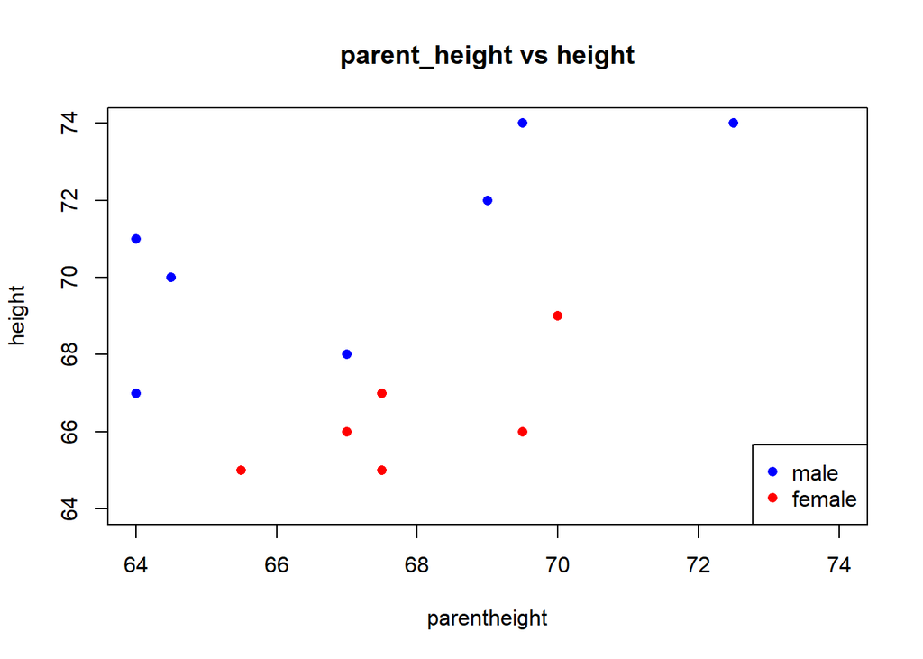

```r
plot(x=c(64,74),type="n",xlim=c(64,74),main="parent_height vs height",ylab="height",xlab="parentheight")
points(parheight_m,height_m,pch=16,col="blue")
points(parheight_f,height_f,pch=16,col='red')
legend("bottomright",c("male","female"),col=c("blue","red"),pch=c(16,16))
```

### c

as the plot shows it **might be linear**,  
and it is positive direction,  
it’s variation is big, because it is vary from average pattern,  
it **do not have outliers**,  
the difference of male and female is that **female is almost shorter than male even though their parents’ height is the same**, but both of male and female have linear positive pattern

### d

```r
male_d=height_m-parheight_m
female_d=height_f-parheight_f
```

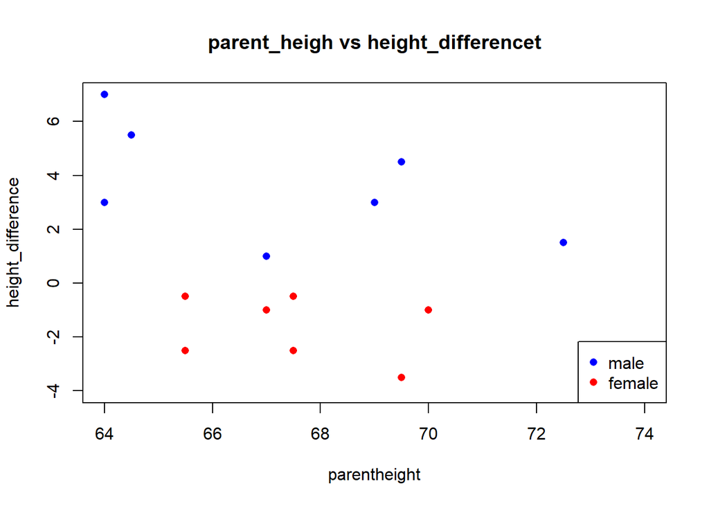

```r
plot(x=c(-4,7),type="n",xlim=c(64,74),main="parent_heigh vs height_differencet",ylab="height_difference",xlab="parentheight")
points(parheight_m,male_d,pch=16,col="blue")
points(parheight_f,female_d,pch=16,col='red')
legend("bottomright",c("male","female"),col=c("blue","red"),pch=c(16,16))
```

the graph reveal that **male often taller than parents and female often shorter than parents**,  
even though male and female have the same parent height, they could have different height_difference which female are almost negative and male positive,  
**so the gender of people might be another factor to effect height, it might be a subgroup**

## 3.24

### a

**the slope of line is -2.34, which means as latitudes increase one, the January temperatures will estimate to decrease 2.34**

### b

```r
yhat_d=(126-2.34*40)-(126-2.34*42);yhat_d
```

```
## [1] 4.68
```

```r
y_d=25-29;y_d
```

```
## [1] -4
```

the predicted difference by equation is 4.68, which means Pittsburgh is hotter than Boston.  
but the actual difference is -4, which means Pittsburgh is cooler than Boston.

### c

```r
126-2.34*33
```

```
## [1] 48.78
```

the predicted average January temperature for a city with latitude 33 is **48.78**

### d

there are two cities in the table have the latitude 33, Phoenix and Dallas, with there actual average January temperature is 43 and 54, respectively.  
Phoenix’s residual is $43-48.78=-5.78$ which means it is overestimate, the actual temperature is lower than predict, **the city is cooler than predict**  
Phoenix’s residual is $54-48.78=5.22$ which means it is underestimate, the actual temperature is higher than predict, **the city is warmer than predict**

## 3.48

### a

because SSTO(sum of squared total) means the sum of squared differences between observed y values and the sample mean ybar,  
which **only depends on y** and has no relationships with x  
so no matter what explantory variables is, the SSTO is the same

### b

**the mid-parent height explains the most variablity in students’ height**  
because the SSR of it is 122.4, which is bigger than other two

### c

```r
88/284
```

```
## [1] 0.3098592
```

**the $r^2$ is 0.3099**,which is the ratio of $SSR/SSTO$ ，describe the strength of a linear relationship,the value means the explantory variable explains 30.9% of the variation among the observation of response variable

## 3.62

### a

```r
113.6-1.01*0
```

```
## [1] 113.6
```

the estimated August temperature is **113.6** at the latitude 0

### b

**because it is extrapolating**, all the data is between latitude 26~47, so it is not good to use it to estimate latitude out of this range, it has a high probability to be false

## 3.82

### a

the slope is -0.1184, so the correlation between winning time and year is **negative**,which means adding one year the winning time will decrease, also can say that if want to win in closed year you need to run faster

### b

```r
272.63-0.1184*2010
```

```
## [1] 34.646
```

the predicted winning time is 34.646, the actual time is 34.91, so the residual is 0.264,  
which means **predicteded and actual is almost closely, but the prediction is a little be underestimate**, the actual winning time is longer than predicted one

### c

```r
4*-0.1184
```

```
## [1] -0.4736
```

as the Olympic game occur every 4 years, we mulitiply -0.1184 by 4, which means **adding one time of Olympic game, the winning time would decrease 0.4736 second**

### d

**because it is extrapolating**, all the data is between 1924~2006, so it is not good to use it to estimate 2080 winter Olympic, it has a high probability to be false

## r practice

```r
veh=read.csv("Vehicles.csv",sep=",",header=T)
head(veh)
```

```
##   Year Vehicle  GDP
## 1 1992 2907022 5615
## 2 1993 3238754 6205
## 3 1994 3570497 6784
## 4 1995 3874203 7397
## 5 1996 4146475 8037
## 6 1997 4411911 8717
```

### scatterplot

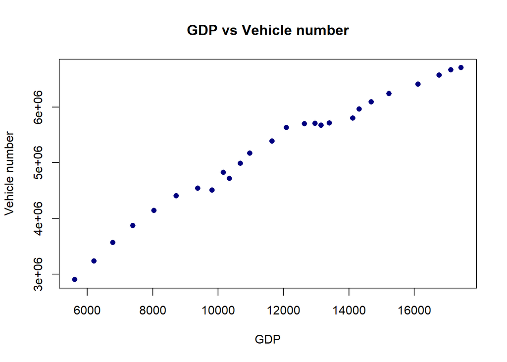

```r
vehicle=veh$Vehicle
GDP=veh$GDP
plot(vehicle~GDP,pch=16,cex=1,col="navy",main="GDP vs Vehicle number",xlab="GDP",ylab="Vehicle number")
```

the plot is linear, positive, have low variance, and no have outlier

### correlation coefficient 相關係數

```r
cor.test(GDP,vehicle)
```

```
##
##  Pearson's product-moment correlation
##
## data:  GDP and vehicle
## t = 29.886, df = 24, p-value < 2.2e-16
## alternative hypothesis: true correlation is not equal to 0
## 95 percent confidence interval:
##  0.9704225 0.9941627
## sample estimates:
##     cor
## 0.98683
```

the correlation coefficient is 0.98683, which is very strong positive linear association

### simple linear regression

```r
RESULTS=lm(vehicle~GDP)
summary(RESULTS)
```

```
##
## Call:
## lm(formula = vehicle ~ GDP)
##
## Residuals:
##     Min      1Q  Median      3Q     Max
## -413891 -113513    3883  119749  334703
##
## Coefficients:
##              Estimate Std. Error t value Pr(>|t|)
## (Intercept) 1.606e+06  1.251e+05   12.84 3.06e-12 ***
## GDP         3.055e+02  1.022e+01   29.89  < 2e-16 ***
## ---
## Signif. codes:  0 '***' 0.001 '**' 0.01 '*' 0.05 '.' 0.1 ' ' 1
##
## Residual standard error: 175800 on 24 degrees of freedom
##   (1 observation deleted due to missingness)
## Multiple R-squared:  0.9738, Adjusted R-squared:  0.9727
## F-statistic: 893.2 on 1 and 24 DF,  p-value: < 2.2e-16
```

#### coefficient

```r
RESULTS$coefficients
```

```
##  (Intercept)          GDP
## 1605510.4932     305.5035
```

the 迴歸係數 is 305.5035, which means as GDP increase 10億元 the sale of vehicle increase 305.5035  
and the intercept is 1605510.5  
so the equation is saling car numbers =1605510.5+305.5*GDP

#### residual

```r
head(RESULTS$residuals)
```

```
##           1           2           3           4           5           6
## -413890.617 -262405.679 -107549.203    8883.155   85632.918  143326.542
```

```r
mean(abs(RESULTS$residuals))
```

```
## [1] 135145.5
```

the mean of absolute residuals is 135145.5, which means the difference of actual and estimated value

#### estimated y (yhat)

```r
head(RESULTS$fitted.values)
```

```
##       1       2       3       4       5       6
## 3320913 3501160 3678046 3865320 4060842 4268584
```

this is the estimate value of saling vehicle number

#### plot

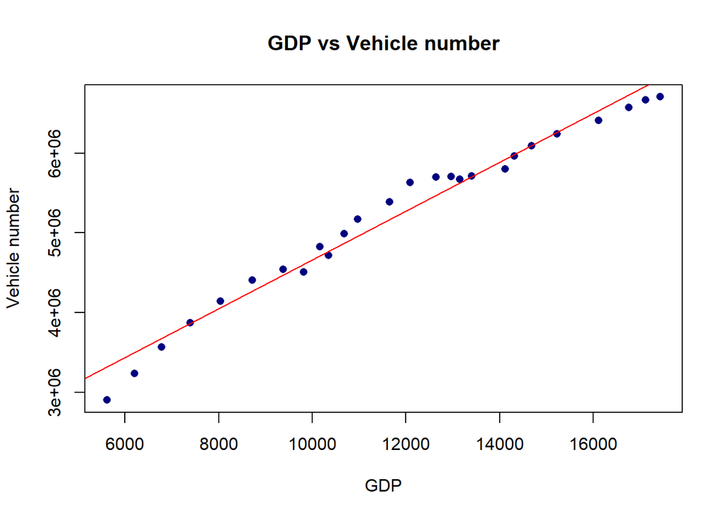

```r
plot(vehicle~GDP,pch=16,cex=1,col="navy",main="GDP vs Vehicle number",xlab="GDP",ylab="Vehicle number")

abline(RESULTS,col="red")
```

the plot is linear, positive, have low variance, and no have outlier, and the dots is close to the regression line

#### 看SSR跟SSE

```r
anova(RESULTS)
```

```
## Analysis of Variance Table
##
## Response: vehicle
##           Df     Sum Sq    Mean Sq F value    Pr(>F)
## GDP        1 2.7609e+13 2.7609e+13   893.2 < 2.2e-16 ***
## Residuals 24 7.4185e+11 3.0910e+10
## ---
## Signif. codes:  0 '***' 0.001 '**' 0.01 '*' 0.05 '.' 0.1 ' ' 1
```

the SSR is 2.7609e+13, the SSE is 7.4185e+11, so the r-square is 0.9738, which is really high, it means that GDP can explain 97.38% of the increase or decrease of the saling of vehicle